# 1980年巴菲特致股东的信

沃伦.巴菲特

董事会主席

1981年2月27日

致Berkshire公司全体股东：

1980年本公司的营业利润为4,190万美元，较1979年的3,600万美元成长，但期初股东权益报酬率(持有股票投资以原始成本计)却从去年的18.6%滑落至17.8%。我们认为这个比率最能够作为衡量公司管理当局单一年度经营绩效的指针。当然要运用这项指针，还必须对包含会计原则、资产取得历史成本、财务杠杆与产业状况等在内的主要因素有一定程度的了解才行。

各位在判断本公司的经营绩效时，有两个因素是你必须特别注意的，一项是对公司营运相当有利的，而另一项则企业绩效相对较不利的。让我们先从好的那一面看起：

**无控制权持股之盈余**

当一家公司拥有另一家公司部分股权时，在会计上通常有三种方式来处理投资公司在被投资公司所拥有的权益，其中所持有的股权多寡将决定公司采用何种方式。

一般公认会计原则规定若持有股权比例超过百分之五十(除了少数例外，就像我们先前持有的银行股份)，则投资公司必须完全合并该被投资公司，包含营收、费用、所得税与盈余等在内的所有会计科目。比如说像是伯克希尔持有60%股权的蓝筹邮票公司，便是属于这一类，至于其它40%股东的权益在财务报表上则以少数股东权益列示。

而若是持有股权比例介于20%-50%之间，像Wesco金融公司虽系由伯克希尔所控制但却仅持有48%的股权，则在投资公司的账上仅记录一个分录，将被投资公司依股权比例所确认的投资损失或利益予以入账。因此如果A公司拥有B公司三分之一的股权，则不论B公司是否将年度盈余全数发放，A公司都必须依比例确认投资利益，另外这两类的会计原则都规定，必须附带一些企业间所得税、购买法价格调整等调整分录，这部分的细节请容我们以后有空再详加说明，(虽然我知道大家可能等不及了)。

最后若是持股比例低于20%，则依照会计原则，投资公司仅能确认被投资公司实际发放的股利部分，至于保留而不发放的部分盈余则不予理会，也因此假若我们持有一家X公司10%的股份，又假设X公司在1980年共计赚了1,000万美金，若X公司将盈余全部发放，则我们可确认100万的利益，反之若X公司决定保留全部盈余不予发放，则我们连一毛钱都不能确认。

之所以强迫大家上了堂稍微简单的会计课的原因在于，伯克希尔将发展的重点集中于保险事业，使得其资源大量集中投注于第三类的股权投资(亦即持股比例小于20%)之上，这些被投资公司仅将它们所赚盈余中的一小部分以现金股利的方式分配给我们，这代表其获利能力仅有一小部分呈现在我们公司的账上，但就经济实质面来说，那只是实际获利的冰山一角而已，这类投资近年来因为我们旗下保险事业蓬勃发展，同时也因为股票市场出现许多不错的投资机会而大幅增加，股票投资的大量增加再加上这些公司本身获利能力的增长使得我们实际获得的成果相当可观，以去年来说，光是保留在这些公司而未分配给伯克希尔的盈余，便比伯克希尔整年度的账面盈余还高，虽然这样的情况在一般企业界并不多见，但我们预期这种情况在伯克希尔将会持续出现。

我们本身对投资盈余如何确认的看法与一般公认会计原则并不尽相同，尤其是在目前通货膨胀高涨之际更是如此，(但话说回来批评要比修改这套原则要容易多了，有些问题早已是根深蒂固了)，我们有些100%持股的转投资公司账面上所赚的钱，实质上并不足那个数，即使依照会计原则我们可以完全地控制它，(就理论而言，我们对他具有控制权，但实际上我们却必须被迫把所赚到的每一分钱，继续投注在更新资产设备，以维持原有生产力，并赚取微薄的利润)，相较之下，我们也有一些仅持有少数股份而其所赚的盈余远超过账面列示之数，甚至其所保留的资金还能为我们赚取更多的盈余。

因此对伯克希尔而言，对盈余的认定并非取决于持股比例是100%、50%、20%、5%或是1%，盈余的真正价值在于其将来再投资所能产生的效益，这与是否由我们自己或是专业经理人来决定并不相关，也与我们确认或不确认利益不相关(重要的是剧本而不是演员)。假设我们公司拥有一片山林，即使财务报表无法反映这些树木的成长，也无法掩盖我们拥有这片成长中的山林这项事实。

我必须提醒诸位，这样的论点是突破传统的，我们宁愿将所赚的盈余能够继续交由不受我们控制的人好好发挥，也不希望转由我们自己来浪费。

**企业长期绩效**

如先前所提的，我们以营业利润除以股东权益(股权投资以原始成本计)来评估企业单一年度的绩效，至于长期评量的标准，则须加计所有已实现或未实现的资本利得或损失，而一直以来，后者历年来的平均数都比前者还要好，最主要的原因是前段所提那些无控制权的公司盈余持续累积，反映在其市值增加之上。

当然市值的变化起伏不定且无法预测，更无法真正量化到底数字是多少，有时一个高价买进的错误，甚至可能把公司往后十几年盈余累积的效果都给抵销掉，但是只要市场恢复理性，市价终究会反映公司累积盈余的能力，甚至超过买进后累积的盈余，这等于是在蛋糕上多得到一点奶油。

在现有经营阶层接掌伯克希尔的十六年来，公司每股的账面净值(其中保险事业的股权投资以市价计)已由原先的19.46美元成长至400.8美元，相当于年复合成长率20.5%(事实上你“本身”做得也不错，过去十年来人体内所含矿物质成份的价值以年复合成长率22%增加)，值得庆幸的是，虽然我们也犯了不少错，但还是能达到这样的记录，尽管管理上时常遭到三振，但优异的企业体质仍然可以维持相当不错的平均打击率。

我们旗下的保险事业将会持续地把资金投资在一些虽不具控制权但经营良好且保留大部分盈余的公司之上，按照这个策略，可预期的长期的投资报酬率将持续大于每年账面盈余的报酬率，而我们对此理念的坚信不移是很容易用数字来说明的，虽然只要我们愿意，把手上的股权投资出清，然后转进免税的长期债券，公司每年账面盈余马上就能净增加3,000万美金，但我们从来就没想过要那么去做。

**股东权益报告**

很不幸的，公司财务报表所记载的盈余已不再表示就是股东们实际上所赚的，只有当购买力增加时，才表示投资获得真正的盈余。假设当初你放弃享受十个汉堡以进行投资，期间公司分配的股利足够让你买两个汉堡，而最后你处分投资后可换八个汉堡，那么你会发现事实上不管你拿到是多少钱，你的这项投资实际上并无所得，你可能觉得更有钱，但不表示你可以吃的更饱。

高通货膨胀率等于是对投入的资本额外扣了一次税，如此一来可能使得大部分的投资变得有点愚蠢，而近几年来这个基本门槛不断提高，使得扣除通胀后投资的实际回报有增长越来越难，每个纳“税”人就好像是在一个向下滑的扶梯上拼命往上跑一样，最后的结果却是愈跑愈往后退。

举例来说，假设一位投资人的年报酬率为20%(这已是一般人很难达到的成绩了)而当年度的通胀为12%，又若其不幸适用50%高所得税级距，则我们会发现该位投资人在盈余全数发放的情形下，其实质报酬率可能是负的，因为这20%的股利收入有一半要归公库，剩下的10%全部被通货膨胀吃光，不够还要倒贴，这结局可能比在通胀温和时投资一家获利平庸的公司还不如。

假设若只有外在的所得税负而无隐性的通货膨胀税负，则不论如何，正的投资报酬永远不会变成负的(即使所得税率高达90%也一样)，但通货膨胀却不管公司账面到底赚不赚钱，只要像是最近这几年的通胀，就会使得大部分公司的实质投资报酬由正转为负，即使有些公司不必缴纳所得税也是一样，举例来说，如果通货膨胀率达到16%，约有六成的美国企业股东其实际投资报酬率变为负值，即使大家都不必缴纳资本利得与股利所得税也一样。

当然这两者租税是交相存于在现实社会中的，因为外在的课税系按照名义所得而非实际所得，所以在支付所得税后，股东的实际所得将不增反减。

而以目前的通货膨胀率来看，我们相信对适用中高级距所得税率的投资人而言(除非你是透过退休基金、慈善团体等免税机构来投资)，将无法从投资一般美国企业获得任何实质的资本利得，即使他们把分配到的股利一再重复地投资下去也一样，因为其获利早已被隐藏的通货膨胀与台面上的所得税给吸收殆尽。

而如同去年我们所说的一样，对于这个问题我们目前无解(明年我们的回答很可能也是如此)，通货膨胀对我们股权投资的报酬没有任何一点帮助。

编制指数(Indexing)是一般认为对抗通胀的一种有效方法，但大部分的企业资本却从未这样做，当然账面每股盈余与股利通常会渐渐增加，若公司把所赚的钱再投资下去，即使是无通胀也是一样，就像是一个勤俭的薪水阶级，只要固定把他所赚薪水中的一半存入银行，就算是从来没有获得加薪，他每年的收入还是会慢慢的增加。

理论上，企业盈余(当然不包括由额外投入的资本所产生的盈余)不必增加任何资金，也能够稳定地随着物价指数持续增加，包含营运资金在内，但只有极少数的公司具有此种能力，而伯克希尔并不在其中。

当然本公司在盈余再投资以求成长、多元化、茁壮的企业政策下，碰巧也有为股东减轻外在所得税负的效果，那就是只要你不将目前所持有的伯克[希尔股份](https://xueqiu.com/S/OC833154?from=status_stock_match)转做其它投资，就不会被课征所得税，但是隐藏的通货膨胀税，却是每天你醒来就必须面对的问题。

**盈余报告**

蓝筹邮票及Wesco两家公司因为本身是公开发行公司以规定编有自己的年报，我建议大家仔细阅读，尤其是有关Louie Vincenti和Charlie Munger对联合储贷业务所作的改造，若有需要伯克希尔的股东可向Mr.Robert(地址：加州洛杉矶5801 South Eastern Avenue)索取蓝筹邮票的年报或向Mrs.Bette(地址：加州Pasadena 315 East Colorado Boulevard)索取Wesco的年报。

就像先前我们所提到的，那些不具控制权的股票投资其未分配盈余的重要性已不下于前面表列的账面盈余，至于那些已分配的部分则透过确认投资收益列示在保险公司投资收益项下。

不具控制权的股权投资的收益来源单位：千美金

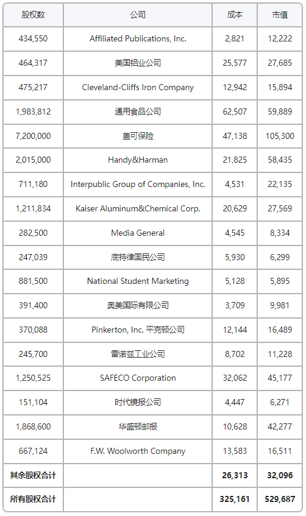

从本表你会发现本公司背后所创造盈余的动力系来自于各行各业，所以我们只能看个大概，譬如保险子公司约持有Kaiser Alumnium 3%和Aloca 1.25%的股份，在1980年我们光是从这些公司依持股比例可得约1,300万美金(当然若将这些盈余实际转为资本利得或股利，则大约会被课以25%的税负)，因此单单在制铝这门行业，我们的经济利益就大于其它那些我们可以直接控制且须详尽报告的公司。如果我们的持股不改变，则制铝产业的景气变动，将比那些我们具有实质控制权的产业，对本公司长远的绩效表现更有影响力。

**GEICO保险公司**

目前我们不具控制权的股权投资最大的部位就是持有33%股权，约720万股的GEIGO，通常若持有一家公司股权达到这样的比例(超过20%)，便必须采用权益法每年依比例确认其投资损益，但由于伯克希尔当初系依照政府部门特别命令购买该公司股份，其中规定须将此投票权交由一公正第三人管理，所有失去投票权，意味伯克希尔对GEICO不具实质控制权。(Pinkerton也有类似的状况)。

当然是否确认损益对伯克希尔及其股东而言，并不影响其实质的经济利益，这些盈余的实际价值将取决于运用它们的GEIGO经营阶层能力的高低。

关于这一点，我们再满意不过了，GEIGO可说是投资业界的最佳典范，它具有难以模仿的产业优势，同时加上高超的资金管理技巧。如你所见到的，我们的持股成本约4,700万美元，分别是在1976年与1980年分两次投入，依历史分红情况，我们每年约从GEIGO确认300万元的利益，但实际上每年可分得的盈余却高达2,000万元，换言之，我们光是在该公司未分配的盈余就达伯克希尔账面盈余的四成左右。

另外我们必须强调的是我们完全赞同GEIGO经营阶层将剩下属于我们的1,700万保留起来未分配的作法，因为在此同时，GEIGO于近两年内陆续买回自家股票，使得该公司流通在外的股份由3,400万股缩减至2,100万股，大大增进了原有股东的权益，如此对待股东的方式实在是无话可说。

过去几年我们一再提到买进那些具有转机题材的产业令人大失所望的结果，这些年我们大约接触了数百家这样的公司，最后不管是真正投入与否，我们都持续追踪其后续发展，在比较过预期以及实际的表现后，我们的结论是，除了少数的例外，当一个赫赫有名的经营者遇到一个逐渐没落的夕阳产业时，往往是后者占了上风。

GEIGO或许是一个例外，自1976年几乎破产的边缘东山再起，从经营阶层Jack Byrne上任的第一天起优异的表现，正是它能获得重生的最大因素。当然即使身陷于财务与经营危机当中，GEIGO仍享有其最重要的产业竞争优势也是重要关键。

身处于广大市场中(汽车保险)，不同于大部分营销组织僵化的同业，一直以来GEIGO将自己定位为低营运成本的公司，所以能够在为客户创造价值的同时，也为自己赚进大把钞票，几十年来都是如此，而即使它在七零年代中期发生危机，也从未减弱其在此方面的经济竞争优势。

GEIGO的问题与1964年[美国运通](https://xueqiu.com/S/AXP?from=status_stock_match)所爆发的色拉油丑闻事件类似，两家公司皆为一时之选，一时的打击并未毁掉其原本的经济基础，就像是一个身体健壮的人得到局部可切除的肿瘤，只要遇到一位经验丰富的医生，就能化险为夷。

不论怎么说，我们还是很高兴能够以4,700万美元的代价买到GEICO的持股，因为透过谈判并购方式想要买下一家类似具有经济特质与光明前景，且每年可创造2,000万盈余的公司，至少得花上2亿美金(有些产业的要价可能还更高)，虽然100%的持股更可使所有权人得以掌握公司的生杀大权，同时也会给企业总部带来一些乐趣(这点通常比较少人会提到)。

对于保险业规定，我们只能取得绩优企业的部分少数股权(以远低于买下整家企业的价格投资)，(这代表我们不能更换经营阶层、无法对资金做重新配置甚至处理公司)，我们从来就不会感到任何不妥，在企业经营的世界里，Jack Byrnes或GEICO都算是少数，能够以伙伴的关系与它们共同合作有何不可呢?

**保险产业现况**

保险产业的情况持续依我们先前所预期般地发展，综合比率从1979年的100.6升高到1980年估计的103.5，可预期的是1981到1982年这个趋势将继续持续下去，业界的核保损失将向上攀升，想要了解个中原因的人，我建议你读读Chubb保险集团的年报，其对产险业竞争态势所作的精辟分析，虽然报告不见得令人振奋，但绝对中肯。

而不幸的是，一个尚未浮现但却非常棘手的问题使得保险业的阵痛将持续，它不但使得保险公司因核保损失创下历史新高而面临经营的困境，更有可能让从业者苦心经营的努力事倍功半。

事情的起因在于债券价格下跌，而会计原则又允许保险业以摊销成本而非市价列示其账面价值，结果导致许多从业者以摊销成本记录的长期债券投资金额达到其净值的二、三倍之多，换言之，只要债券价格下跌超过三分之一，便很有可能把公司的净值全部吃光，这其中甚至包括好几家知名的大公司在内，当然债券价格也有可能会回升，使得其部分，甚至全部的净值得以回复，但也没有人敢保证债券价格不会继续下跌。(我们深信对股票或债券价格所作的短期预测根本是没有用的，预测这件事或许能够让你更了解预测者本身，但对于了解未来却是一点帮助也没有)。

有点诡异的是，若持有的股票投资组合价格下跌会影响到保险从业者的生存，但若换作是债券价格下跌却是一点事都没有，保险从业者所持的理由是不管现在的市价是多少，反正只要到期日前不卖出，便能按照票面赎回，所以短期间价格的波动并无太大影响，就算是二十年、三十年或甚至是四十年后到期，只要我不卖，等时间一到，就能够按票面金额收回，反倒是若我现在就出售这些债券，那么就算是再买进同类型价值更高的债券，我反而要立即确认相关损失，使得账面净值因而大幅缩水。

但真正的情况却是，从业者很可能为避免确认损失而一直不敢出售债券，其结果反而错失其它更好的投资机会。

更严重的是，保险公司资金主要是来自于保户所缴的保费，由于产险的投保期间较短，一旦保户规模缩减，资金流动不足时，将被迫出售部分债券使得损失浮上台面，保险公司的净值立即大幅缩水。

因此保险公司在面临债券价格下跌，净值大幅缩水(目前确有许多从业者是如此)，同时市场费率又低到不合理时，通常有两种选择，一种是告诉核保部门，必须坚守费率底限，保费绝对不可以低于预估损失成本加上营业费用。

这种选择的结果相当明确:(a)由于大部分的业务都是每年更新且对价格都相当敏感，所以很多保单在到期后都会流到竞争对手那边(b)随着保费收入大幅缩水，相对应的负债科目也会慢慢减少(未到期保费及应付理赔款)(c)资产(债券)必须跟着出售，以因应负债的减少(d)原先台面下的未实现损失，将被迫确认在保险从业者的财务报表之上(当然要看出售的多寡)。

此种令人沮丧的动作，对于净值影响程度不一，有些公司在(c)阶段的反应是出售成本与市价相当的股票，或是新进投资损失较小的债券，出售好的投资，留下烂的部分的这种驼鸟心态，短期间或许较不觉得痛，但对于公司与产业长远的发展皆会产生重大的伤害。

第二种选择比较简单，那就是不管保费水准有多低，将来要赔多少钱，都照单全收以维持现有保费收入水准，然后暗地里祈祷不要发生什么重大意外，或是期待债券价格早日回升，对于这样的做法，外界一直有相当大的批评。

当然各位都晓得我们应该采取那一种做法，而且产业的趋势也很明确，那就是只要大部分的保险公司都被迫采取第二种做法，那么保险市场就不会有好转的一天，因为如果大部分的从业者，不论费率是否合理，都以维持保费收入水准为第一优先，那么市场价格就一定不会好转，除了本身发生财务问题之外，我们最不愿意见到的就是市场上大部分的同业都因为财务问题而纷纷采取流血式的杀价竞争。

我们之前也曾提到，任何一家保险公司因为种种理由，诸如顾及公众反应、企业自尊心或是怕伤害到净值等原因，而不愿认赔出售债券者，终将发现自己被债券长期套牢而无法进行其它投资，而我们之前也提到，问题还不止于此，除了投资的选择被迫牺牲，甚至连是否接受保单的选择也都荡然无存。

至于我们本身采取的立场就相当令人安心，我们相信自己的净值相对于保费收入水准，参照所有从业者债券采摊销成本制，是所有大型产险从业者中最强的，甚至当债券价值以市价计时，我们的竞争优势更加明显，(当然在吹嘘自夸的同时，我们还是必须提醒自己资产与负债部位的到期日仍不相称，而且本人也因为无法坚强的执行，而使得我们在债券方面的投资损失了不少钱)。

伯克希尔充足的资金与弹性的投资操作，将使得我们在面对市场不当定价的恶性竞争环境时，还能游刃有余，但是产业的问题就是我们的问题，我们坚强的财务实力，依旧无法使我们免于产业的杀价竞争，我们只不过是多了些持久力以及可供选择的空间。

**保险业营运**

今年由Phil Liesche所领导的国家产险公司在核保部门Roland以及理赔部门Bill Lyons的协助下，不断地超越自我，虽然保费收入持平，但核保的利润率却创同业新高，虽然我们预期明年保费收入将减少，但身为总部的我们不会有任何的抱怨而他们的薪资考核也不会受影响，对于公司创始人所定下的核保准则我们信奉不渝，而且相当清楚一旦失去就永难再恢复。

John Seward领导的家庭与汽车险公司则小有进展，我们将较不具竞争力的小额一般责任险转为金额较大的汽车保险，同时随着核保绩效的改进，营运规模，不论是在地区或是产品线，也在缓步提升中。

再保业务部分由于进入障碍较小，还是持续受到供过于求的局面，加上初级保险从业者面临的问题，事前可先收取巨额保费，但灾害真正发生与理赔时程却拉得很长，这种感觉有点像青少年第一次拥有自己的信用卡一样。

高利润的吸引力使得大笔的资金拥入这个行业，目前的高利率环境更加深了这样的现象，导致的结果是若某一年未发生大灾难，则往后几年的核保绩效便会变得很差，相反的，若有大灾难发生，则更大的灾难将会降临在保险公司身上，因为有些同业可能无法履行与客户当初签订的合约，而我们George Young在这一行的表现一向是一流的，在加计投资收益后，仍能微持合理的获利，我们将继续留在再保市场，但在可预见的未来，保费收入将很难有大幅的成长。

在Homestate家计保险业务方面，我们持续面临重大的问题，除了Kansas的Floyd Taylor外，其余的核保表现均在同业水准之下，其中Iowa保险，自1973年成立以来，每年皆发生巨额损失，直到去年我们决定结束该州的业务，并将之并入Cornhusker产险，家计保险概念其实也很大的潜力，但还需要很多努力才有办法实现它。

我们的劳工退休金业务在去年痛失英才，37岁的Frank不幸去世，他天生就是个保险专家，[积极进取](https://xueqiu.com/S/CSI1032?from=status_stock_match)，努力上进，在短短时间内便改正在国家产业退休金业务部门的缺失，当初介绍Frank加入的Dan立即接手其原有工作，并以伯克希尔以另一家子公司Redwood火险为主体，承接业务。

至于由Milt所领导的Cypress保险公司一直是我们在这项业务的主力，且表现一直相当优异，与Phil Liesche一样，广为同业所仰慕与模仿，但其优秀的表现却是同业无法比拟的。

总之保险业务量在1981年将大幅下滑，整体核保表现也不会太好，虽然我们预期自己的绩效应该会比同业好许多，但其它同业也都这样认为，最后肯定有人会大失所望。

**纺织业及零售业营运**

去年我们缩减在纺织业的营运规模，虽然不愿意但却不得不关闭Waumbec工厂，除了少数设备转移至New Bedford外，其余设备连同厂房都将处理掉，我本人由于无法早日面对事实而犯了重大的错误。

而在New Bedford我们也淘汰了将近三分之一的织布机，保留适合少量多样型的机台，而即使一切顺利(这种情况很少)，这些生产线仍不具投资效益，就产业循环而言，损失将无可避免。

剩下的纺织事业，规模还不算小，将划分为制造与销售两部门，各自独立运作，两者才不至于绑在一起，由于新购进中古130吋针式织布机，将使得我们目前最具获利能力产品线的产能增加一倍，情势告诉我们纺织业又将面临艰困的一年，所幸我们在这一行所投入的资本已大幅减少。

Ben在联合零售商店的表现持续令我们惊艳，在零售业普遍惨淡的一年，该公司盈余表现仍佳，且大部分皆为现金收入，而明年联合零售将迈入第五十个年头，而连同前任者Simon(1931-1966)，两人合计经营这家公司整整有五十年了。

**伊利诺国家银行及Rockford信托处分案**

1980年底，我们终于完成了以伯克希尔的股份交换41,086股Rockford Bancorp(其持有97.7%伊利诺[国家银行](https://xueqiu.com/S/NKSH?from=status_stock_match)股份)的动作。

交换的方式准许伯克希尔股东维持各自在该银行的权益(除了我本人仅能维持原来的80%)，如此他们将可确保在该银行的权益与传统的分割方式一样受到保障，总计有24位股东(目前股东总人数为1,300人)选择了这种对等方式。

另外股东们也可要求增加其在该银行的权益(相对地，其在伯克希尔的权益将减少)，所有提出此项要求的股东皆如愿拿到股票，因为这39位股东需求的股份数量刚好略低于其它1,200多位选择全数保留伯克[希尔股份](https://xueqiu.com/S/OC833154?from=status_stock_match)所释出的银行股份，剩下的中间差额则由本人承受(约占Bancorp 3%的股份)，在加计先前基本80%的分配额度后，最后的结果，本人在银行的权益稍微减少，而在伯克希尔的权益则略微增加。

银行的经营团队对于这样的结果感到满意，Bancorp将成为一个只有65位股东，组织单纯且不复杂的控股公司。

**财务**

8月份，我们发行了12.75%，25年期(2005年到期)，金额6,000万美元的公司债，依合约规定我们将于1991年开始提存备偿基金。这项融资案的主要承销商Donaldson自始至终皆提供我们一流的服务。

不像大部分的公司，伯克希尔并不会为了一些特定的短期资金需求而去融资，我们借钱反而是因为当我们觉得在一定期间内(约略短于融资年限)将有许多好的投资机会出现，最佳的投资机会大多是出现在市场银根最紧的时候，那时候你一定希望拥有庞大的火力。

对于并购的对象，我们偏爱那些会“产生现金”而非“消化现金”的公司。由于高通货膨胀的影响，越来越多的公司发现它们必须将所赚得的每一块钱再投入才能维持其原有的营运规模，就算这些公司账面数字再好看，除非看到真实的现金，我们对之仍保持高度警戒。

符合我们标准的公司并不容易发现，(每年我们研究上百件的并购案，其中仅有少数能引起我们的兴趣)，所以要让我们规模合理稳定扩充的想法并不容易落实，但我们仍将持续多方尝试以保持伯克希尔的成长。

无论如何，我们皆希望能够保持适当的流动性，负债比例与结构适当并保留充裕的资本实力，虽然这种保守的态度将使得我们的投资报酬率因此打了点折扣，但这也是惟一能让我们感到安心的一种方式。

**其他事项**

Gene Abegg我们长期投资的Rockford银行创办人，于七月二日逝世，享年八十二岁，身为一位挚友、银行家与杰出公民，他是无可超越的。

当你向某个人买下一家公司时，你对这个人有了更多的了解，之后你又请他以员工而非老板的身份继续经营这家公司。在买卖开始前，他对这家公司了若指掌，而你却一无所知，卖方有太多机会可以欺骗买方，而当交易完成后，微妙(但又不那么微妙)的态度开始改变而模糊的认知也会发酵，就像是求婚的过程一般，失望总是难免的。

而当我们第一次碰面，Gene百分之百坦诚，就像是其为人一般，谈判的开始，他把公司所有负面的因素摊开在桌上，另一方面，在交易完成数年后，他还会定期地告知你当初交易时未讨论到的地方。

而就算是当他把银行卖给我们时已高龄71岁，Gene仍然辛勤工作更甚于以往，虽然极少发生问题，但一有问题便立刻报告毫不迟疑，你还能对这样的人多要求些什么呢?(早在1933年该银行所持有的现金便足以立即清偿所有存款)，他永远记得他是在处理别人的钱财，虽然这种正直不阿的态度将永远安息，但他杰出的管理能力将使银行在全美获利能力的表现上继续名列前茅。

Gene负责伊利诺[国家银行](https://xueqiu.com/S/NKSH?from=status_stock_match)的营运将近50年，约当美国历史的四分之一，当初是一位工业巨子George Mead从芝加哥把他找来Rockford开设银行，Mead先生负责出钱，Gene则负责出力，他的领导才能立即在Rockford地区各种社交活动中展现出来。

许多Rockford的居民告诉我这些年来Gene给予他们很多帮助，有时是金钱上的，但更多时候包含的是智能、同情与友谊，而我本身也从他身上获得许多，因为个别年纪与工作上的关系，我们亦师亦友，不论如何，这种关系相当特殊，我永远怀念他。